# Modelos Lineares Generalizados

# 11 Gráficos de Efeitos

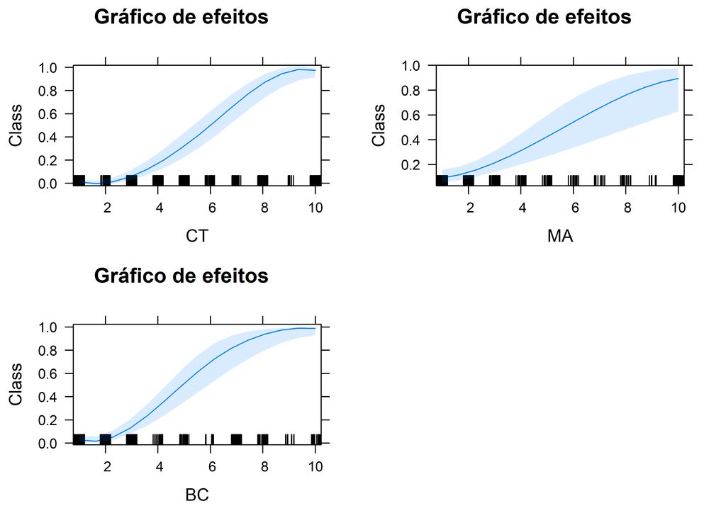

```r
# Gráfico de efeitos marginais de cada variável
plot(allEffects(ajuste), type = 'response', main = 'Gráfico de efeitos')
```

# 12 Razão de chance (odds ratio) e IC para RC

A razão de chance é o exponencial da estimativa pontual. Os intervalos de confiança para as razões de chance (odds ratio – OR), fixando o nível de confiança de 95%: (**encontrei em um tutorial**: http://www.estatisticacomr.uff.br/?p=598)

A razão de chances pode ser interpretado como o aumento estimado na probabilidade de sucesso associada a mudança em uma unidade no valor da variável do preditor linear.

```r
# Razões de chance
(OR <-exp(ajuste$coefficients))
 (Intercept)           CT           MA           BC
5.000962e-05 2.488782e+00 1.635058e+00 2.441311e+00
```

```r
# IC para as razões de chance
(IC <- exp(confint.default(ajuste, level=0.95)))
                   2.5 %       97.5 %
(Intercept) 6.518477e-06 0.0003836728
CT          1.941281e+00 3.1906965439
MA          1.323709e+00 2.0196401766
BC          1.833798e+00 3.2500842198

(OR_IC <- cbind(OR, IC))
                      OR        2.5 %       97.5 %
(Intercept) 5.000962e-05 6.518477e-06 0.0003836728
CT          2.488782e+00 1.941281e+00 3.1906965439
MA          1.635058e+00 1.323709e+00 2.0196401766
BC          2.441311e+00 1.833798e+00 3.2500842198
```

**Simulando o aumento de um unidade em CT para responder a questão 1:**

**A questão 1** Para uma unidade a mais no escore de CT (fixados os valores de MA e BC), a chance de um tumor maligno será?

Para descobrir a chance fiz o seguinte:

- Inicialmente, obtive a probabilidade para os seguintes valores das preditoras: CT=4, MA=4 e BC=5, cujo resultado foi: **Y = 0,5432091**;
- Em seguida, simplesmente aumentei uma unidade em CT (isto é, aumentei para 5), então usei novamente as preditoras: CT=5, MA=4 e BC=5, cujo resultado foi: **Y = 1,351929**.
- Finalmente, é fácil verificar que a relação é multiplicativa: **2,4888** * **0,5432091 = 1,351929**.

```r
(Y <- exp(ajuste$coefficients[1]+ajuste$coefficients[2]*4+
               ajuste$coefficients[3]*4+ajuste$coefficients[4]*5)/
   (exp(ajuste$coefficients[1]+ajuste$coefficients[2]*4+
          ajuste$coefficients[3]*4+ajuste$coefficients[4]*5)+1))
(Intercept)
  0.5432091

(Y2 <- exp(ajuste$coefficients[1]+ajuste$coefficients[2]*5+
               ajuste$coefficients[3]*4+ajuste$coefficients[4]*5)/
   (exp(ajuste$coefficients[1]+ajuste$coefficients[2]*4+
          ajuste$coefficients[3]*4+ajuste$coefficients[4]*5)+1))
(Intercept)
   1.351929
```

# 13 Diagnóstico do ajuste

O diagnóstico do ajuste é fundamental em modelos de regressão linear tradicional, e em GLM não é diferente. O principal componente no diagnóstico de MLGs é, novamente, a análise de resíduos. (**Fonte:** slides de aula)

O objetivo principal dessa etapa da análise é a avaliação do modelo ajustado. No caso de MLGs, baseia-se, dentre outros, na verificação dos seguintes itens: (**Fonte:** slides de aula)

- Avaliação da distribuição proposta;
- Avaliação da parte sistemática do modelo;
- Adequação da função de ligação;
- Identificação e avaliação do efeito de observações mal ajustadas;
- Identificação de pontos influentes.

## 13.1 Resíduos (default)

Pode-se, inicialmente, verificar os resíduos usando-se da função **plot** do R. No entanto, por se tratarem de dados binários os gráficos apresentados não são convenientes para analisar os resíduos.

**Cesar Taconelli**: Os gráficos de resíduos através do plot *default* têm comportamento bastante atípico, mas característico da análise de dados binários, devido aos empates.

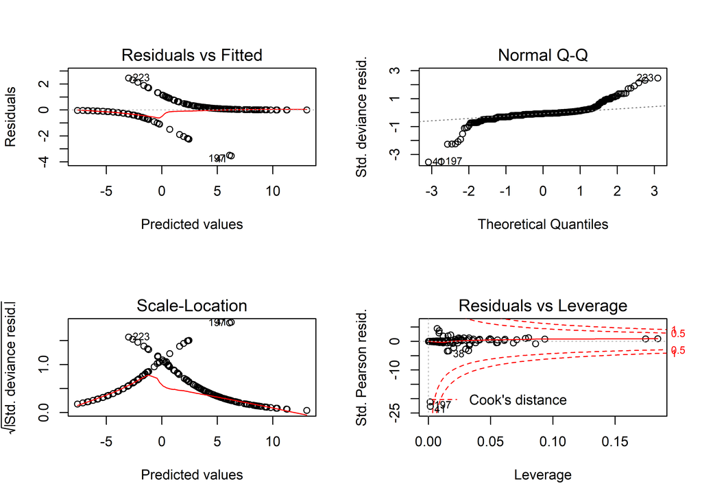

```r
par(mfrow=c(2,2))
breast_aj$res_default <- ajuste$residuals
plot(ajuste)      # gráficos do ajuste (me parece que não são úteis para analisar os resíduos!)
```

O gráfico quantil-quantil normal para os resíduos componentes da deviance:

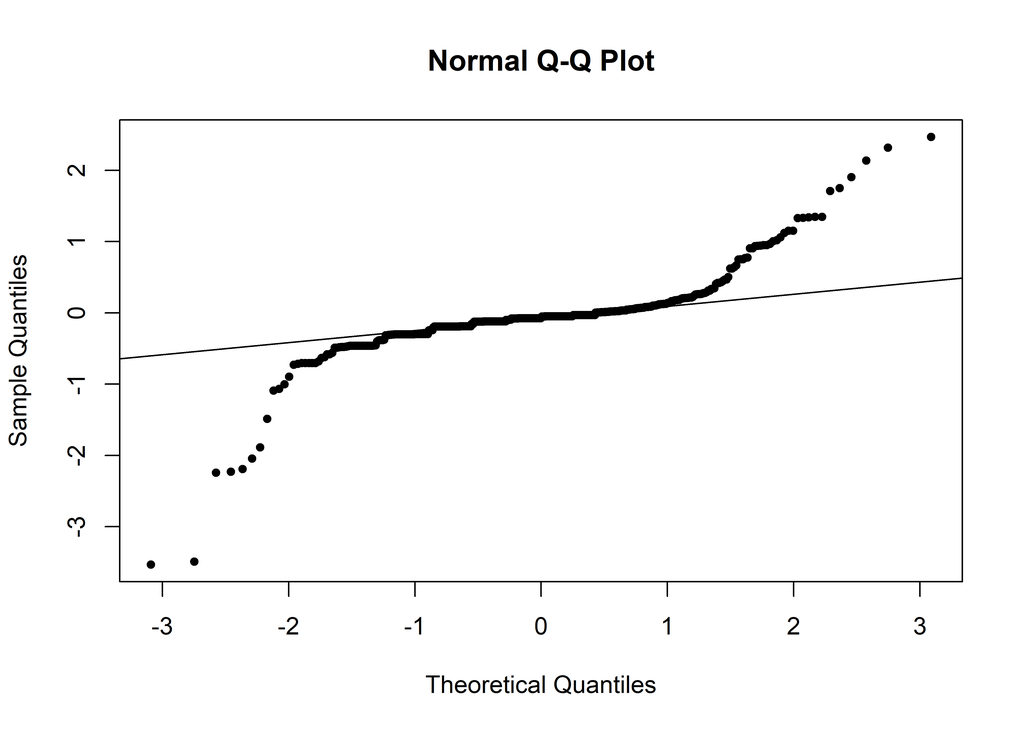

```r
qqnorm(resid(ajuste), pch = 20)
qqline(resid(ajuste))
```

## 13.2 Resíduos Quantílicos Aleatorizados

**Cesar Taconelli**: Para um diagnóstico mais adequado da qualidade do ajuste, é mais interessante usar os **resíduos quantílicos aleatorizados**. Para tanto, o pacote **statmod** dispõe da função `qres.binom()`. Além disso, pode-se usar os gráficos meio-normais com envelope simulado, disponíveis no pacote `hnp`.

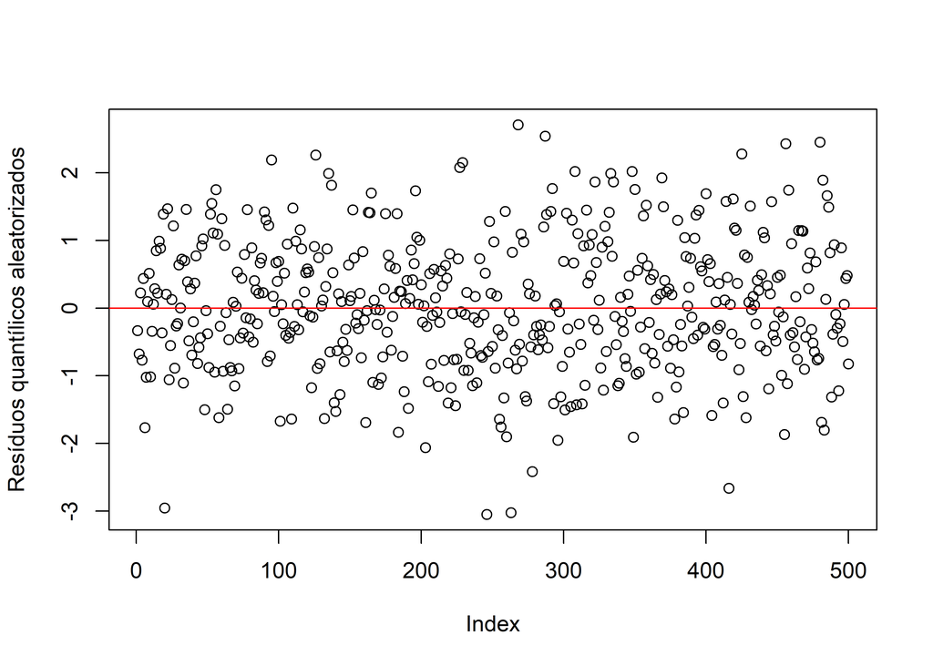

```r
# Resíduos quantílicos aleatorizados
breast_aj$rqa <- statmod::qres.binom(ajuste)  # Calcula os rqa e add ao dataframe "breast_aj"
plot(breast_aj$rqa, ylab = "Resíduos quantílicos aleatorizados")    # Plota os rqa
abline (h =0, col = "red")
```

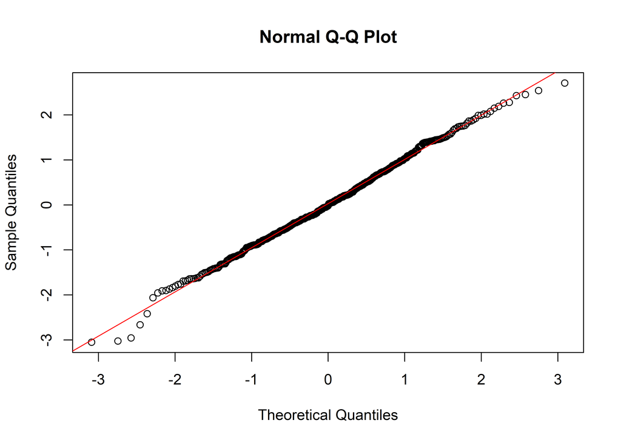

```r
#with(breast_aj, plot(rqa, col='black', xlab='Index', ylab='Resíduos'))
#abline (h =0, col = "red")

# Papel de probabilidade normal
qqnorm(breast_aj$rqa)
qqline(breast_aj$rqa, col = "red")
```

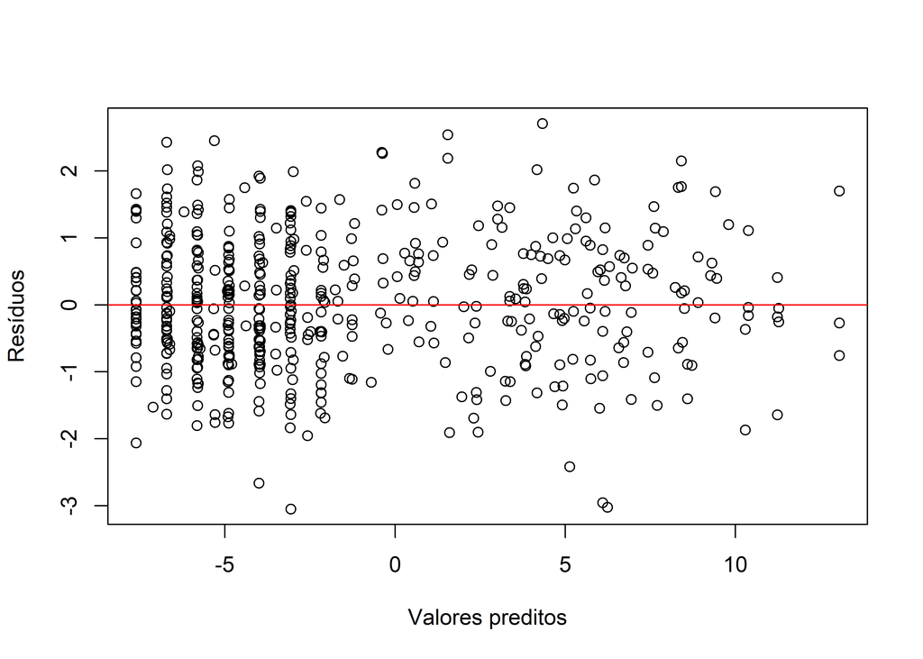

```r
# resíduos versus valores preditos (na escala do preditor)
with(breast_aj, plot(pred_pred, rqa, col='black', xlab='Valores preditos', ylab='Resíduos'))
abline (h =0, col = "red")
```

## 13.3 Envelope Simulado - Função hnp

**Cesar Taconelli**: O padrão para um ajuste adequado é os resíduos (pontos) dispostos no interior do envelope (linhas) simulado. Novamente temos um indicativo de que o modelo está bem ajustado.

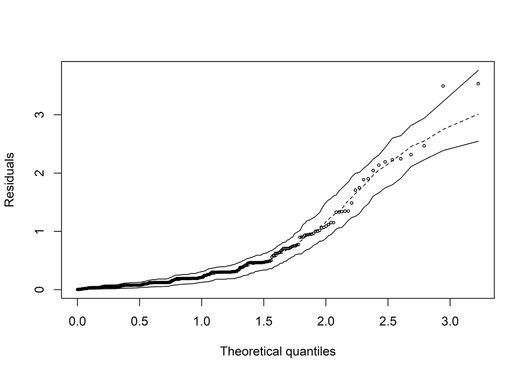

```r
# Envelope Simulado - Função hnp

hnp::hnp(ajuste)
Binomial model
```

# 14 Previsão - Conjunto de validação

O modelo ajsutado foi usado na classificação dos dados de validação. Os seguintes resultados foram obtidos:

- Usando a função **predict** para obter as prediçoes para os dados não usados no ajuste.
- O argumento **type = ‘response’** indica que as previsões devem ser retornadas na escala da probabilidade de **resposta Y**:

No geral, o modelo cometeu apenas 13 erros de classificação. Três tumores foram classificados como malignos quando na verdade eram benignos, e 10 tumores foram classificados como benignos enquanto na verdade eram malignos.

```r
# Prediçoes no conjunto de validação
preds <- predict(ajuste, newdata=breast_pred, type='response')

# Matriz de confusão: limiar de probabilidade < 0,5 foi estabelecido. Isto é se a probabilidade estimada for < 0,5 o tumor será classificado como benigno.

(Conf_matrix <- table(preds > 0.5, breast_pred$Class))

        benign malignant
  FALSE    122        10
  TRUE       3        64
dimnames(Conf_matrix)[[1]] <- c('Tumor benigno', 'Tumor maligno')    # renomeando dim[1]
dimnames(Conf_matrix)[[2]] <- c('Tumor benigno', 'Tumor maligno')    # renomeando dim[2]
print(Conf_matrix)                                                   # imprime matriz

                Tumor benigno Tumor maligno
  Tumor benigno           122            10
  Tumor maligno             3            64

#(Conf_matrix <- addmargins(A=Conf_matrix, margin = seq_along(dim(Conf_matrix)[1]))) # adiciona total às colunas
```

**Especificidade**: 122/(122+3)= 0,9760 (97,60%)

**Sensibilidade**: 64/(64+10)= 0,8648 (86,48%)

```r
# Calculando a sensibilidade e sensitividade do modelo
(Esp <- Conf_matrix[1,1]/sum(Conf_matrix[,1]))                # cálculo manual especifidade
[1] 0.976
(Sens <- Conf_matrix[2,2]/sum(Conf_matrix[,2]))                 # cálculo manual sensibilidade
[1] 0.8648649

# Usando o pacote caret
sensitivity(Conf_matrix)
[1] 0.976
specificity(Conf_matrix)
[1] 0.8648649
```

**Fonte**: **Tutorial**: https://docs.ufpr.br/~taconeli/CE22518/Vinheta2.html

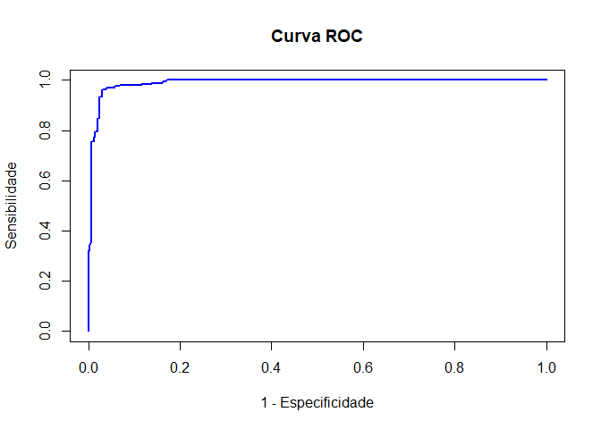

```r
library(ROCR)
pred <- prediction(ajuste$fitted.values, breast_aj$Class)
perf <- performance(pred,"tpr","fpr")
plot(perf, xlab = '1 - Especificidade', ylab = 'Sensibilidade',
     main = "Curva ROC", col = "blue", lwd = 2)
```

```r
area <- performance(pred,"auc")
area@y.values
[[1]]
[1] 0.9892287
```

# 15 Questões propostas

Com base nos resultados apresentados, responda as seguintes questões:

1. Para uma unidade a mais no escore de CT (fixados os valores de MA e BC), a chance de um tumor maligno:
1. É acrescida em 0.9118;
2. Fica multiplicada por 0.9118;
3. É acrescida em 2.4888;
4. Fica multiplicada por 2.4888; (**Correta**)
5. Não se altera.

**R:** A letra **d** está correta.

2. Para nódulos com CT=4, MA=4 e BC=5, a probabilidade estimada do tumor ser maligno é:
1. 0.1732;
2. 0.8268;
3. 0.5432 (**Correta**)
4. 0.4568;

**R:** A letra **c** está correta. (na escala da variável resposta)

3. O limite inferior de um intervalo de confiança 95% para o parâmetro correspondente à variável CT é:
1. 0.2138;
2. 0.6632; (**Correta**)
3. 0.7850;
4. 0.9118;

**R:** A letra **b** está correta.

4. A sensibilidade e a especificidade do modelo são estimadas, respectivamente, por:
1. 0.9552 e 0.9242;
2. 0.8648 e 0.9760; (**Correta**)
3. 0.3216 e 0.6130;
4. 0.7692 e 0.9346;
5. 1 e 1.

**R:** A letra **b** está correta.

5. Com base apenas no gráfico de resíduos apresentado, podemos afirmar que:
1. Os resíduos não têm distribuição normal, e portanto o modelo não está bem especificado;
2. Os resíduos têm distribuição normal, e portanto o modelo está bem especificado;
3. Os resíduos não têm distribuição binomial, e portanto o modelo não está bem especificado;
4. Os resíduos têm distribuição binomial, e portanto o modelo está bem especificado;
5. Nenhuma das afirmações é necessariamente verdadeira. (**Correta**)

**R:** A letra **e** está correta.